# Évaluation de l'algorithme de recherche de trajet SNCF 🚆

Ce notebook présente :

- Le fonctionnement de l'algorithme de recherche d'itinéraire.
- Pourquoi et comment nous avons mis à jour le dataset SNCF.
- Des exemples de trajets calculés.
- Un exemple de requête API et sa réponse.

## 🔍 Explication approfondie de l'algorithme de Dijkstra

### Comprendre et valider son fonctionnement

L'algorithme de **Dijkstra** est une méthode classique pour **trouver le chemin le plus court dans un graphe pondéré**.  
Dans notre cas, le graphe représente **le réseau ferroviaire SNCF**, où :

- **Chaque nœud** est une ville possédant au moins une gare.
- **Chaque arête** est une liaison ferroviaire directe entre deux villes.
- **Chaque poids d'arête** correspond au **temps de trajet** en minutes.

L'algorithme fonctionne en :

1. **Initialisant** la distance de tous les nœuds à l'infini sauf le point de départ.
2. **Parcourant** les voisins du nœud courant et mettant à jour leur distance.
3. **Marquant** les nœuds comme visités pour éviter les boucles.
4. **Répétant** jusqu'à atteindre la destination.

#### **📌 Pourquoi Dijkstra est un bon choix ?**

Dijkstra garantit que **chaque ville est atteinte par le chemin optimal en temps de trajet** en raison de :

- **Sa structure de file de priorité**, qui traite toujours **le chemin le plus court découvert en premier**.
- **Son absence de cycles** (on ne revisite pas une ville déjà visitée avec un temps plus court).
- **Son exploration progressive**, qui sélectionne **le prochain meilleur itinéraire en fonction des données disponibles**.

Nous allons voir **comment l'algorithme explore les trajets possibles** et **pourquoi il sélectionne le bon chemin** pour **Rennes → Biarritz**.

## 🛤️ Étude détaillée du fonctionnement sur Rennes → Biarritz

### Décomposition du trajet avec Dijkstra

Prenons un exemple réel : **calculer le chemin le plus rapide entre Rennes et Biarritz**.  
Dijkstra va explorer **toutes les routes possibles** pour **trouver l’itinéraire optimal en temps**.

#### **🎯 Objectifs :**

1. Partir de **Rennes** et atteindre **Biarritz**.
2. Minimiser **le temps total de trajet**.
3. Réduire **le nombre de changements de train** si possible.

L'algorithme se déroule en plusieurs étapes :

#### 📍 **Étape 1 : Initialisation**

- La gare de **Rennes** est définie comme le **point de départ** avec un coût de **0 minutes**.
- Toutes les autres villes sont **marquées comme infiniment éloignées**.
- Une **file de priorité** est utilisée pour **traiter en premier les trajets les plus courts**.

```
🎯 **Départ :** Rennes (temps : 0 min)
```

#### 📍 **Étape 2 : Exploration des premières connexions**

Dijkstra commence à explorer **les villes accessibles directement depuis Rennes**,  
en mettant à jour **les meilleurs temps trouvés**.

```
⏳ Étape 1: Exploration de Rennes (temps cumulé : 0 min)
⏳ Étape 2: Exploration de Betton (temps cumulé : 5 min)
⏳ Étape 3: Exploration de Cesson-sévigné (temps cumulé : 5 min)
...
📌 L'algorithme continue à explorer d'autres chemins de manière optimisée...
```

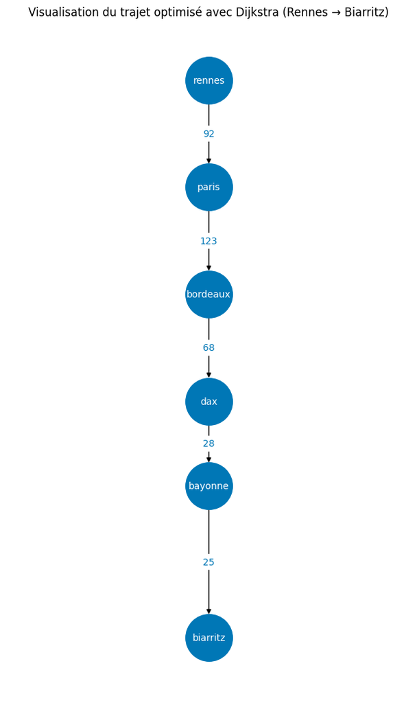

## 🔎 Comparaison avec les autres itinéraires possibles

### 📌 Pourquoi ce chemin est optimal ?

L'algorithme aurait pu emprunter d'autres trajets, mais voici pourquoi il les a ignorés :

[output not shown]

## 📊 Mise à jour du dataset SNCF

Les fichiers SNCF originaux étaient **vieillissants**, manquant de nombreuses données **TGV** et d'arrêts récents. Nous avons donc :

- Récupéré des données plus récentes via **Open SNCF Data**.
- Nettoyé les doublons et structuré les trajets de façon plus efficace.
- Créé un fichier `organized_trips.csv` plus propre et plus facile à exploiter.

Le fichier mis à jour contient les colonnes :

- **Ville de départ** / **Ville d’arrivée**
- **Gare de départ** / **Gare d’arrivée**
- **Temps de trajet** (en minutes)
- **Coordonnées GPS**

## 🚄 Exemples de trajets calculés

### 🏙️ Trajet direct Rennes → Paris :

```
{
    "departure": "rennes",
    "destination": "paris",
    "route": [
        {
            "id": "Rennes",
            "name": "rennes",
            "latitude": 48.103517,
            "longitude": -1.672744,
            "travel_time": 0
        },
        {
            "id": "Paris Gare de Lyon Hall 1 - 2",
            "name": "paris",
            "latitude": 48.844945,
            "longitude": 2.373481,
            "travel_time": 92
        }
    ],
    "total_travel_time": 92,
    "stops": 1
}
```

### 🏖️ Trajet non direct Rennes → Biarritz :

```
{
    "departure": "rennes",
    "destination": "biarritz",
    "route": [
        {
            "id": "Rennes",
            "name": "rennes",
            "latitude": 48.103517,
            "longitude": -1.672744,
            "travel_time": 0
        },
        {
            "id": "Paris Gare de Lyon Hall 1 - 2",
            "name": "paris",
            "latitude": 48.844945,
            "longitude": 2.373481,
            "travel_time": 92
        },
        {
            "id": "Bordeaux Saint-Jean",
            "name": "bordeaux",
            "latitude": 44.825233,
            "longitude": -0.556875,
            "travel_time": 123
        },
        {
            "id": "Dax",
            "name": "dax",
            "latitude": 43.720472,
            "longitude": -1.049801,
            "travel_time": 68
        },
        {
            "id": "Bayonne",
            "name": "bayonne",
            "latitude": 43.496635,
            "longitude": -1.470057,
            "travel_time": 28
        },
        {
            "id": "Biarritz",
            "name": "biarritz",
            "latitude": 43.459387,
            "longitude": -1.545937,
            "travel_time": 25
        }
    ],
    "total_travel_time": 336,
    "stops": 5
}
```

## 🌍 Exemple de requête API et réponse retournée

```
curl -X POST http://localhost:8002/api/sncf/find-route
-H "Content-Type: application/json"
-d '{"sentence": "Je veux aller de Rennes à Paris"}'
```

```
📥 **Réponse de l'API :**
{
    "departure": "rennes",
    "destination": "paris",
    "route": [
        {
            "id": "Rennes",
            "name": "rennes",
            "latitude": 48.103517,
            "longitude": -1.672744,
            "travel_time": 0,
            "stop_name": ""
        },
        {
            "id": "Paris Gare de Lyon Hall 1 - 2",
            "name": "paris",
            "latitude": 48.844945,
            "longitude": 2.373481,
            "travel_time": 92,
            "stop_name": ""
        }
    ],
    "total_travel_time": 92
}
```